```python
import pandas as pd
import matplotlib.pyplot as plt
```

```python
wy = pd.read_csv('https://raw.githubusercontent.com/edsmi/projekt/main/wy%20-%20Arkusz3.csv')
```

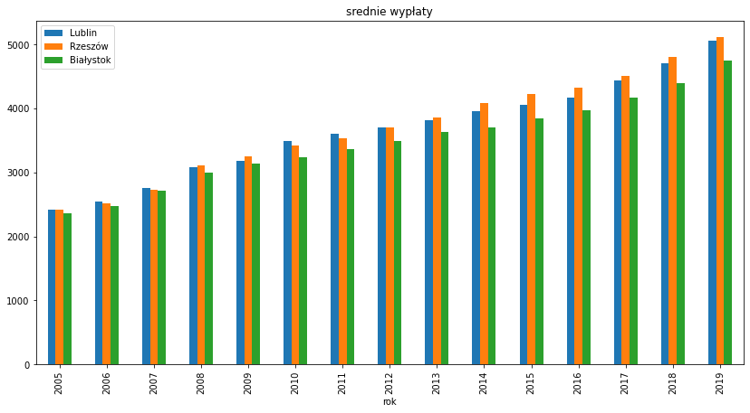

```python
plt.figure(figsize=(25, 16))
wy.plot.bar(x="rok", y=["Lublin","Rzeszów","Białystok"],title="srednie wypłaty",figsize=(14, 7))
```

Na wykresie dotyczących średnich miesięcznych płac dla poszczególnych miast widać że Lublin i Rzeszów maja podobne poziomy plac a za to średnia miesięczna placa w Białymstoku ma mniejszy przyrosc na przełomie ostatnich 14 lat niż Rzeszów czy Lublin

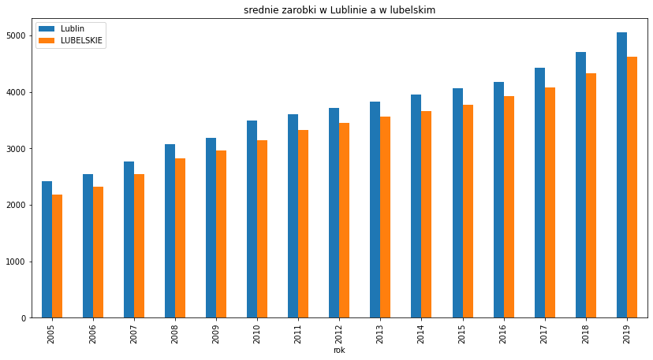

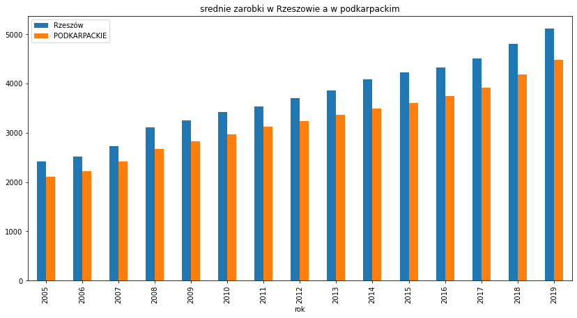

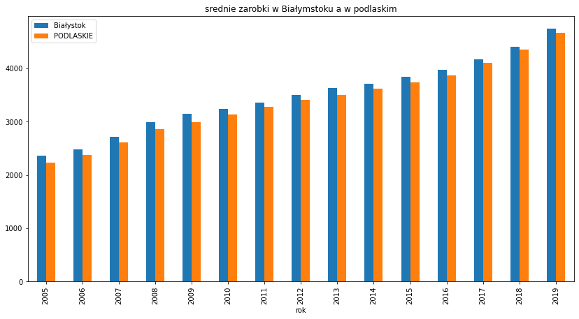

```python
wy.plot.bar(x="rok", y=["Lublin","LUBELSKIE"],title="srednie zarobki w Lublinie a w lubelskim",figsize=(14, 7))
wy.plot.bar(x="rok", y=["Rzeszów","PODKARPACKIE"],title="srednie zarobki w Rzeszowie a w podkarpackim",figsize=(14, 7))
wy.plot.bar(x="rok", y=["Białystok","PODLASKIE"],title="srednie zarobki w Białymstoku a w podlaskim",figsize=(14, 7))
```

Dla Rzeszowa i Lublina widać duże różnice pomiedzy średnimi zarobkami dla miasta a średnimi zarobkami dla województwa. Dla Białegostoku jest mała róznica pomiedzy zrobkami dla miasta a dla województwa podlaskiego.

```python
prze = pd.read_csv('https://raw.githubusercontent.com/edsmi/projekt/main/Arkusz%20kalkulacyjny%20bez%20tytu%C5%82u%20-%20Arkusz3.csv')
```

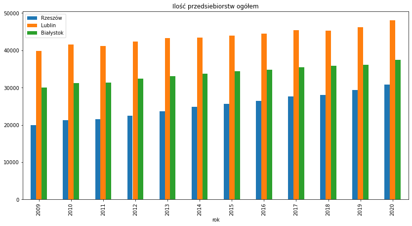

```python
prze.plot.bar(x="rok",y=["Rzeszów","Lublin","Białystok"],title="Ilość przedsiebiorstw ogółem",figsize=(14, 7))
```

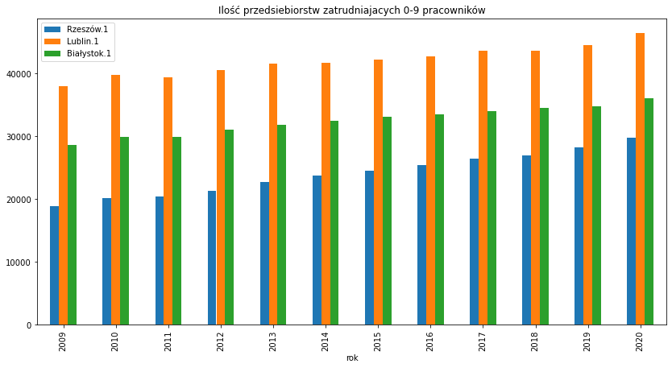

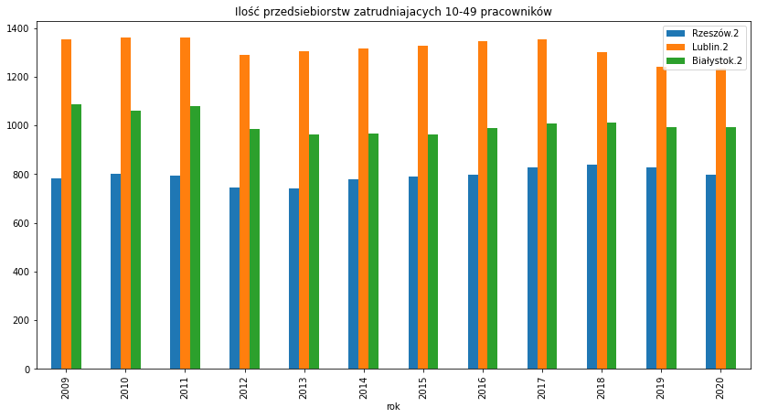

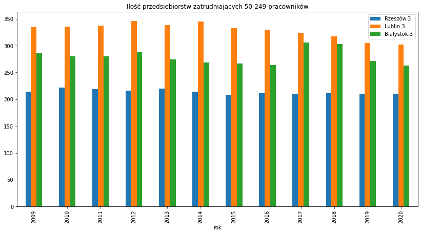

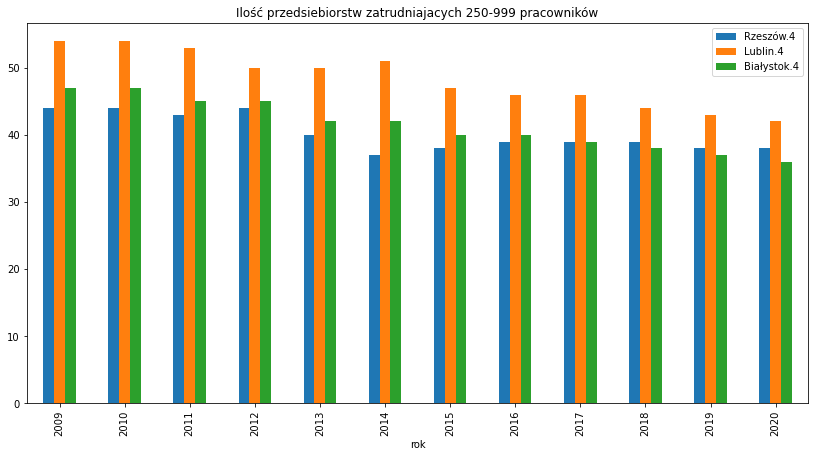

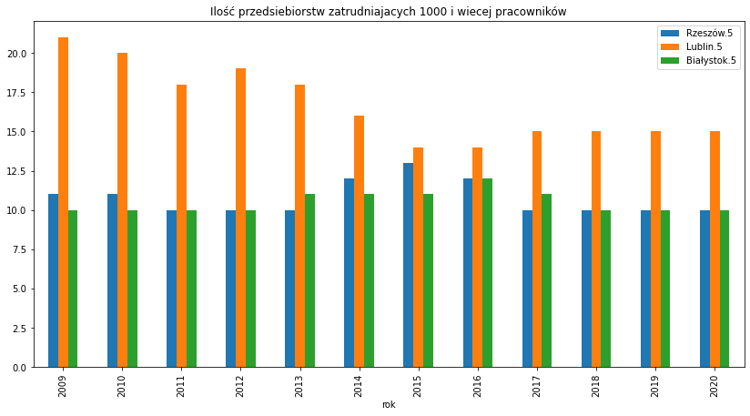

```python
prze.plot.bar(x="rok",y=["Rzeszów.1","Lublin.1","Białystok.1"],title="Ilość przedsiebiorstw zatrudniajacych 0-9 pracowników",figsize=(14, 7))
prze.plot.bar(x="rok",y=["Rzeszów.2","Lublin.2","Białystok.2"],title="Ilość przedsiebiorstw zatrudniajacych 10-49 pracowników",figsize=(14, 7))
prze.plot.bar(x="rok",y=["Rzeszów.3","Lublin.3","Białystok.3"],title="Ilość przedsiebiorstw zatrudniajacych 50-249 pracowników",figsize=(14, 7))
prze.plot.bar(x="rok",y=["Rzeszów.4","Lublin.4","Białystok.4"],title="Ilość przedsiebiorstw zatrudniajacych 250-999 pracowników",figsize=(14, 7))
prze.plot.bar(x="rok",y=["Rzeszów.5","Lublin.5","Białystok.5"],title="Ilość przedsiebiorstw zatrudniajacych 1000 i wiecej pracowników",figsize=(14, 7))
```

```python
prze["Rzeszów049"]=prze["Rzeszów.1"]+prze["Rzeszów.2"]
prze["Rzeszów250"]=prze["Rzeszów.4"]+prze["Rzeszów.5"]
prze["Lublin049"]=prze["Lublin.1"]+prze["Lublin.2"]
prze["Lublin250"]=prze["Lublin.4"]+prze["Lublin.5"]
prze["Białystok049"]=prze["Białystok.1"]+prze["Białystok.2"]
prze["Białystok250"]=prze["Białystok.4"]+prze["Białystok.5"]
```

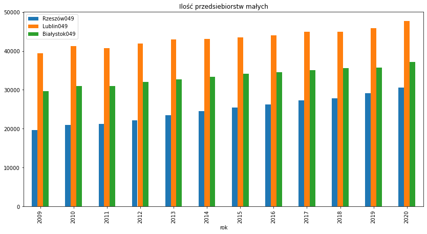

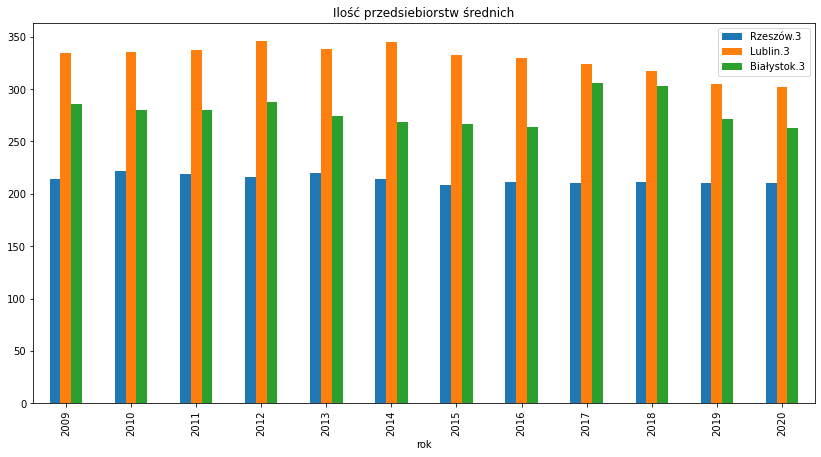

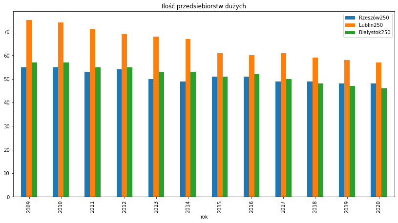

```python
prze.plot.bar(x="rok",y=["Rzeszów049","Lublin049","Białystok049"],title="Ilość przedsiebiorstw małych",figsize=(14, 7))
prze.plot.bar(x="rok",y=["Rzeszów.3","Lublin.3","Białystok.3"],title="Ilość przedsiebiorstw średnich",figsize=(14, 7))
prze.plot.bar(x="rok",y=["Rzeszów250","Lublin250","Białystok250"],title="Ilość przedsiebiorstw dużych",figsize=(14, 7))
```

```python
pod = pd.read_csv('https://raw.githubusercontent.com/edsmi/projekt/main/podmioty%20gospodarcza%20-%20Arkusz6%20(1).csv')
pod.head()
```

|  | rok | Bialystok | Bialystok.1 | Bialystok.2 | Bialystok.3 | Lublin | Lublin.1 | Lublin.2 | Lublin.3 | Rzeszów | Rzeszów.1 | Rzeszów.2 | Rzeszów.3 |
| --- | --- | --- | --- | --- | --- | --- | --- | --- | --- | --- | --- | --- | --- |
| 0 | 2009 | 30059 | 587 | 29472 | 23595 | 39815 | 753 | 39062 | 29455 | 19925 | 526 | 19399 | 14177 |
| 1 | 2010 | 31264 | 553 | 30711 | 24599 | 41622 | 751 | 40871 | 30878 | 21308 | 525 | 20783 | 15274 |
| 2 | 2011 | 31339 | 581 | 30758 | 24334 | 41187 | 754 | 40433 | 30205 | 21543 | 531 | 21012 | 15219 |
| 3 | 2012 | 32410 | 587 | 31823 | 24765 | 42310 | 769 | 41541 | 30582 | 22406 | 528 | 21878 | 15575 |
| 4 | 2013 | 33085 | 552 | 32533 | 25026 | 43334 | 775 | 42559 | 30980 | 23703 | 528 | 23175 | 15985 |

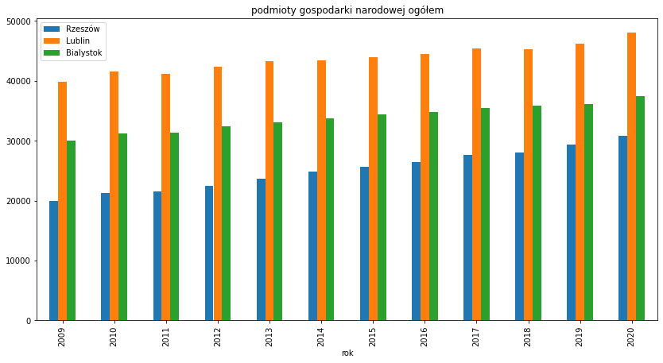

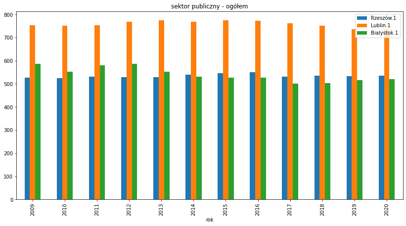

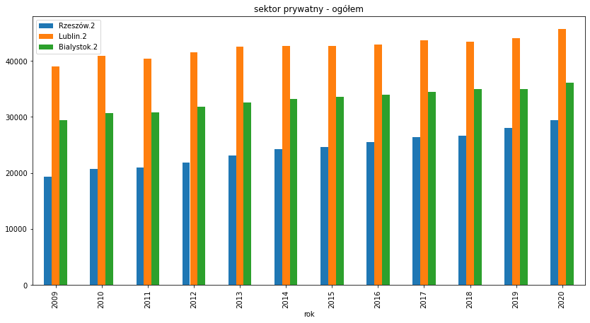

```python
pod.plot.bar(x="rok",y=["Rzeszów","Lublin","Bialystok"],title="podmioty gospodarki narodowej ogółem",figsize=(14, 7))
pod.plot.bar(x="rok",y=["Rzeszów.1","Lublin.1","Bialystok.1"],title="sektor publiczny - ogółem",figsize=(14, 7))
pod.plot.bar(x="rok",y=["Rzeszów.2","Lublin.2","Bialystok.2"],title="sektor prywatny - ogółem",figsize=(14, 7))
```

Dla wartości ogólnych i sektora przywatnego ilości przedsiebiorstw maja podobny wzrostowy rozkład danych. Dla sekstora publicznego wartości utrzymuja stały poziom alecz wystepuja wachania zależnie od roku.

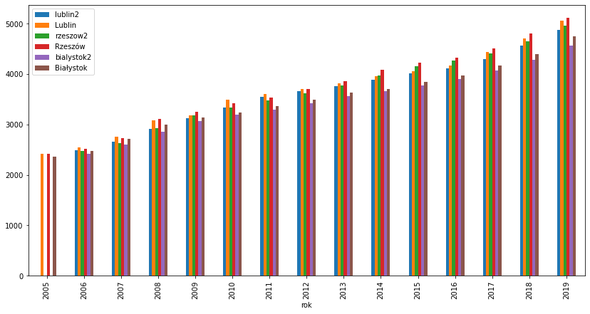

```python
wy.loc[:, 'lublin2'] = wy.Lublin.rolling(2).mean()
wy.loc[:, 'rzeszow2'] = wy.Rzeszów.rolling(2).mean()
wy.loc[:, 'bialystok2'] = wy.Białystok.rolling(2).mean()
wy.plot.bar(x="rok",y=["lublin2","Lublin","rzeszow2","Rzeszów","bialystok2","Białystok"],figsize=(14, 7))
```

Widać ze średnie kroczace wyznaczaja wartość stosunkowo delikatnie mniejsza niz średnie prawdziwe dla danego roku.

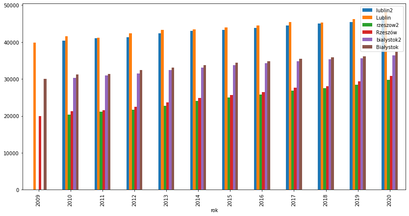

```python
prze.loc[:, 'rzeszow2']=prze.Rzeszów049.rolling(2).mean()
prze.loc[:, 'lublin2']=prze.Lublin049.rolling(2).mean()
prze.loc[:, 'bialystok2']=prze.Białystok049.rolling(2).mean()
prze.plot.bar(x="rok",y=["lublin2","Lublin","rzeszow2","Rzeszów","bialystok2","Białystok"],figsize=(14, 7))
```

średnie kroczące są prawie takie same jak dla wartoci dotyczących ilości małych przedsiębiorstw

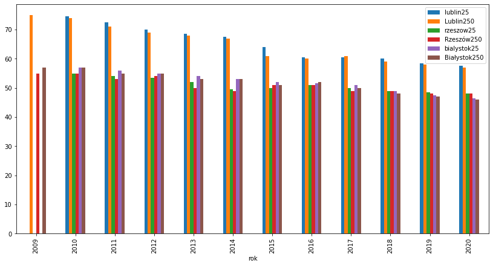

```python
prze.loc[:, 'rzeszow25']=prze.Rzeszów250.rolling(2).mean()
prze.loc[:, 'lublin25']=prze.Lublin250.rolling(2).mean()
prze.loc[:, 'bialystok25']=prze.Białystok250.rolling(2).mean()
prze.plot.bar(x="rok",y=["lublin25","Lublin250","rzeszow25","Rzeszów250","bialystok25","Białystok250"],figsize=(14, 7))
```

Dla dużych przedsiebiorst średnia krącząca jest prawie identyczna jak wartośc ilości duzych przedsiebiorstw